# notebooks

### ALYAN MUHAMMAD DAINURY ISKANDAR | 21041110003

## Estimasi Rata-Rata, Standard Deviasi, Skewness, dan Kurtosis

### Estimasi Rata-Rata

Interval estimasi adalah selompok nilai statistik sampel dalam intervaltertentu yang dapat digunakan untuk melakukan estimasi terhadap parameter populasi dengan harapan bahwa nilai parameter populasi terletak didalam intervaltersebut (Budiarto, 2001, p. 162.)

##### Rumus :

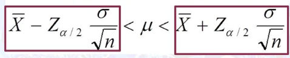

x = rata rata

z = skor berdasar tingkat kepercayaan

σ = standar deviasi

n = jumlah data

### Standard Deviasi

Standar deviasi dalam buku Statistika Hospitalitas diartikan sebagai ukuran sebaran data dalam disiplin statistik yang juga dikenal sebagai simpangan baku. Standar deviasi juga bisa diartikan sebagai akar varian sebaran data.

Sementara itu, Investopedia menyebutkan, standar deviasi adalah nilai statistik yang digunakan untuk menentukan kedekatan sampel statistik dengan rata-rata sebuah data. Semakin tinggi nilai standar deviasi maka semakin lebar pula rentang variasi datanya.

Dengan demikian, standar deviasi bisa memberikan gambaran gap antara nilai sampel terhadap rata-ratanya. Rumus standar deviasi dipakai untuk menanalisis apakah sampel bisa mewakili populasi dalam penelitian. Standar deviasi juga bisa menggambarkan kualitas data sampel yang didapatkan.

Rumus standar deviasi biasa disebut dengan simpangan baku atau dengan simbol σ maupun S. Untuk menentukan standar deviasi diawali dengan menghitung nilai rata-rata dari semua titik data.

### Skewness (Kemiringan)

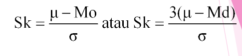

Skewness adalah ukuran ketidaksimetrisan dalam distribusi nilai. Skewness dapat bernilai positif, negatif, dan nol.

Skewness yang bernilai positif berarti ekor distribusi berada di sebelah kanan nilai terbanyak. Berarti, sebagian besar distribusi berada di nilai rendah. Skewness yang bernilai negatif berarti ekor distribusi berada di sebelah kiri, menunjukkan bahwa sebagian besar nilai berada di sisi kanan kurva. Sementara skewness bernilai nol berarti nilai terdistribusi secara simetris, dengan jarak antara ekor distribusi sebelah kanan dan kiri sama besar.

Kriteria untuk mengetahui model distribusi dari koefisien kemiringan :

- Jika koefisien kemiringan <nol, maka bentuk distribusinya negative (ekor bagian kiri lebih Panjang).
- Jika koefisien kemiringan = nol, maka bentuk distribusinya simetrik.
- Jika koefisien kemiringan > nol, maka bentuk distribusinya positif (ekor bagian kanan lebih Panjang).

### Kurtosis (Keruncingan)

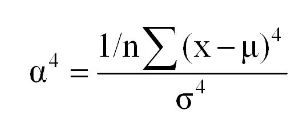

Kurtosis adalah indikator untuk menunjukkan derajat keruncingan (tailedness). Semakin besar nilai kurtosis maka kurva semakin runcing.

Nilai referensi kurtosis adalah 3. Jika nilai kurtosis lebih besar dari 3, maka kurva distribusi disebut leptokurtik. Sementara jika lebih rendah dari 3, maka disebut platikurtik. Sedangkan nilai kurtosis sama dengan 3 bermakna kurva distribusi normal atau mesokurtik atau mesokurtotik.

Kriteria untuk mengetahui model distribusi dari koefisien kurtosis sebagai berikut :

- Jika koefisien kurang dari 3 maka distribusinya adalah platikurtik
- Jika koefisien kurtosis sama dengan 3 maka distribusinya adalah mesokurtic
- Jika koefisien kurtosis lebih dari 3 maka distribusinya adalah leptokurtic.

#### Skewness dan kurtosis dapat menunjukkan kondisi pembagian atau distribusi data. Kondisi ideal adalah saat data terdistribusi normal, yakni saat skewness bernilai 0 dan kurtosis bernilai 3. Semakin jauh dari kondisi ideal berarti data tersebar semakin tidak ideal atau tidak merata.

```python
#estimasi mean
import math

n=math.sqrt(10)
s=7.50
ta=3.250
xbar=53.9

hasil = xbar - ta*s/n, xbar + ta*s/n

print(hasil)
```

```
(46.19194820333958, 61.60805179666042)
```

```python
#standard deviasi
def standar_deviasi(data) :
    jumlah=0
    for i in range (len(data)):
        jumlah+=data[i]

    rata_rata=jumlah/len(data)
    sigma=0
    for i in range (len(data)):
        hitung=(data[i]-rata_rata)**2
        sigma+=hitung
    pembagianN=sigma/len(data)
    cariStandar_Deviasi=pembagianN**0.5
    print("Standar Deviasi adalah: ", cariStandar_Deviasi)

data=[50,58,43,64,47,50,56,47,60,64]
standar_deviasi(data)
```

```
Standar Deviasi adalah:  7.119691004531026
```

# KNN Regresi

K-Nearest Neighbor merupakan metode Supervised Learning untuk mengelompokkan data pembelajaran terhadap objek dengan berdasarkan tetangga terdekat atau jarak yang paling dekat dengan objek . Tujuan dari Algoritma ini yaitu untuk mengelompokkan objek baru berdasarkan atribut dan sample-sample (Training Sample)

Algoritma k- Nearest Neighbor menggunakan klasifikasi ketetanggaan (neighbor) sebagai nilai prediksi dari query instance yang baru. Algoritma ini sederhana, bekerja berdasarkan jarak terpendek dari query instance ke training sample untuk menentukan ketetanggaannya

Kelebihan Algoritma K-Nearest Neighbor Lebih efektif pada data latihnya besar Mudah dipahami dan di Implementasikan Non-linear Karena algoritma K-NN bersifat non-parametik. Menghasilkan data yang lebih akurat Kekurangan Algoritma K-Nearest Neighbor Harus menentukan parameter K (jumlah tetangga terdekat) Sensitif terhadap data outlier Tingginya nilai komputasi Sensitif terhadap perbedaan rentang variabel dan dimensionalitas Sensitif terhadap dimensionalitas yang tinggi.

**Tahapan metode k-Nearest Neighbor:**

- Menentukan parameter k (jumlah tetangga paling dekat).
- Menghitung kuadrat jarak eucliden objek terhadap data sample (data training) yang diberikan.
- Mengurutkan objek-objek tersebut (hasil dari tahapan no. 2) kedalam kelompok dengan cara ascending (berurutan dari nilai tinggi ke nilai rendah).
- Mengumpulkan kategori Y (klasifikasi nearest neighbor) berdasarkan dari nilai k dengan menggunakan kategori mayoritas,maka dapat diprediksikan nilai query instance yang telah dihitung.

Pendekatan Algoritma k-Nearest Neighbor algoritma knn adalah algoritma pembelajaran instance based yang paling banyak digunakan. algoritma knn ini algoritma yang paling sederhana dari algoritma yang lain nya.

Instance merupakan titik dalam ruang n-dimensi dan mendeskripsikan tetangga (neighbor) dalam hal jarak ( Euclidean dalam ruang-R) k merupakan jumlah dari tetangga terdekat (neighbor) k = 1 disebut aturan klasifikasi tetangga terdekat banyak nya jumlah k lebih baik adalah angka ganjil seperti (1, 2, 3, …), untuk menghindari adanya ikatan atau hubungan

```python
import math
Wi = 1
a = 49
b = 46
Wi2 = 3

hasil = (Wi*a+Wi*a+Wi*b)/Wi2

print(hasil)
```

```
48.0
```

# Selang Kepercayaan

Selang kepercayaan (confidence interval) merupakan metode digunakan untuk memperkirakan parameter populasi berdasarkan sampel menggunakan metode statistik tertentu dalam sebuah rentang tertentu. Tujuan menggunakan interval kepercayaan adalah memiliki margin kesalahan sekecil mungkin. Semakin sempit interval, semakin akurat nilai statistik yang kita gunakan.Seperti yang kita tahu, margin of error bentuk toleransi yang mungkin terjadi dalam pengujian statistik. Pada dasarnya, sampel diambil secara acak untuk menghasilkan nilai yang dapat mewakili parameter. Tapi, pengukurannya akan berbeda jika Anda menggunakan sampel lain yang diambil secara acak. Hal ini akan menyebabkan perhitungan yang berbeda. Oleh karena itu, selang kepercayaan adalah solusi untuk memastikan bahwa statistik yang kita hasilkan akurat dalam rentang nilai tertentu (yang merupakan margin kesalahan) dan dapat menggambarkan populasi dengan baik.

Ada tiga faktor yang mempengaruhi margin of error; tingkat kepercayaan, ukuran sampel dan variabilitas dalam populasi.

```python
a = 2.6
b = 1.96
c = 0.05

hasil = a - b*c, a + b*c
print(hasil)
```

```
(2.5020000000000002, 2.698)
```